# Install FFmpeg

Oliver Ehmer

2023-06-07

# English

## Windows

To install *FFmpeg* on *Windows* the program must be downloaded and its location must be specified in an environment variable. This is necessary so that FFmpeg can be started easily in the command prompt or terminal. The steps required for installation are explained below for *Windows 10*.

##### (1) Download

*FFmpeg* can be downloaded from the following site: https://github.com/BtbN/FFmpeg-Builds/releases

On this site, *FFmpeg* is available for various operating systems and under several open source licenses. Be sure to download a .zip file that contains `win64` in the name, e.g. the following:

`ffmpeg-N-102754-g604924a069-win64-lgpl.zip`

If the above link does not work, an alternative link is available on the FFmpeg main page https://ffmpeg.org/download.html.

##### (2) Unzip

The .zip file will be located in your Downloads folder after downloading. Find the file and extract it. (Right click on the file > “Extract all…”)

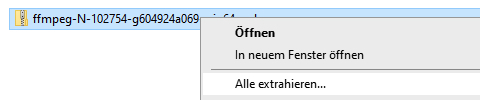

##### (3) Rename the folder

After unpacking, you will get a folder with the overall name of the original .zip file.

Inside it, there is a subfolder with the same name. Rename this folder to ffmpeg (right click > “Rename”.)

[figure not shown]

This folder has two subfolders named doc and `bin`. The `doc` folder contains documentation, the `bin` folder contains various program files, among them the file `ffmpeg.exe` .

##### (4) Move the folder

Move the newly renamed `ffmpeg` folder to the main level of your hard disk `C:\` .

To do this, first select the `ffmpeg` folder and press the key combination *CTRL + X* (to cut).

Then navigate to the main level of your hard disk `C:\` and press the key combination *CTRL + V* (to paste).

The folder `ffmpeg` should now be on the main level of the hard disk C: and the folder bin should be directly inside it.

[figure not shown]

##### (5) Open Advanced System Properties

In the search bar next to the Start menu icon, type `Advanced System Properties`.

[figure not shown]

From the list of search results, select the “Advanced System Properties” app.

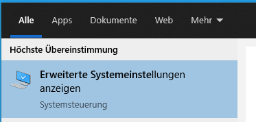

The „System properties“ window opens.

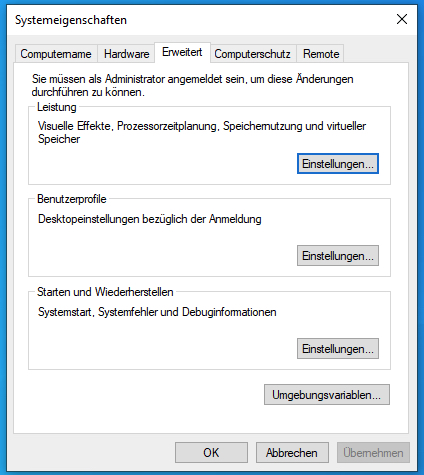

##### (6) Open environment variables

Select “Environment variables…” on this window.

The “Environment variables” window opens.

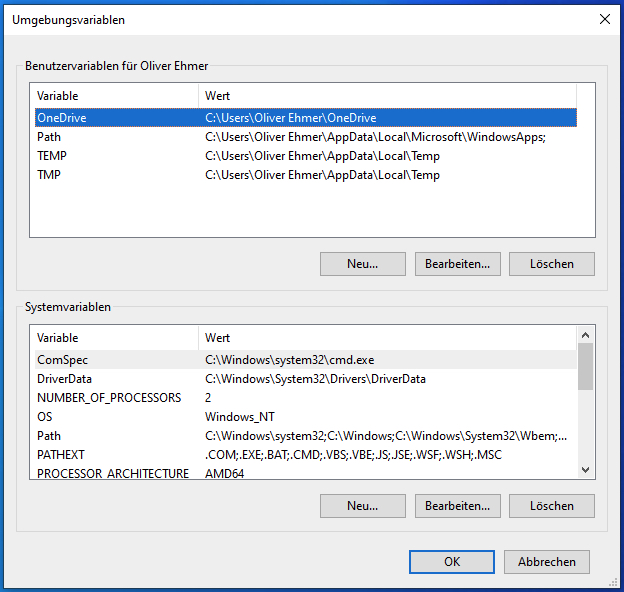

##### (7) Changing the “Path” variable

Click on the “Path” entry in the upper “User variables” area. Then select “Edit…”.

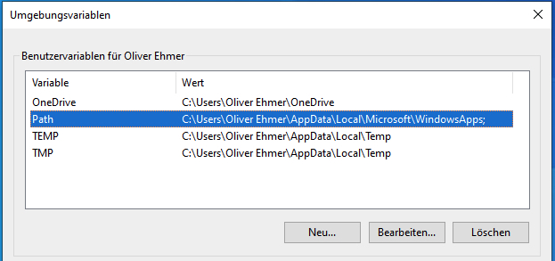

Another window opens.

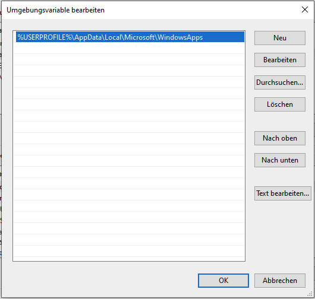

Select the “New” command here.

One of the lines is then activated. Enter the following string: `C:\ffmpeg\bin`

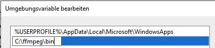

(This is the path to the folder where the program ffmpeg.exe is located).

Click “OK”

Close the “Environment Variables” window with “OK”

Close the “System Properties” window with “OK”

##### (8) Testing the installation

In the search bar next to the Start menu icon, type “Command Prompt.”

[figure not shown]

Select the Command Prompt app from the list.

[figure not shown]

A terminal window will open.

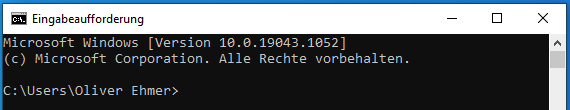

Enter the following command:

`ffmpeg -version`

[figure not shown]

If the installation was successful, you will receive the adjacent output with the version information.

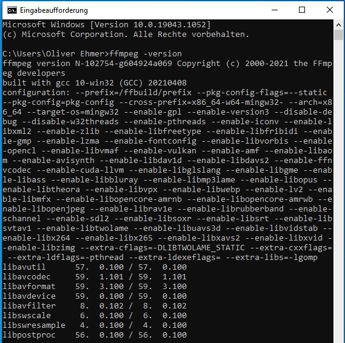

If an error occurs, you will receive the adjacent message that *FFmpeg* could not be found.

If this does not help, check if the path in the environment variable “Path” is specified correctly and points to the folder where you saved `ffmpeg.exe` .

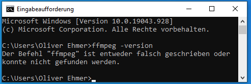

## macOS

For installation on *macOS* the package manager *homebrew* can be used. The following steps are necessary for installation.

##### (1) Installing XCode

*XCode* can be installed for free via the Apple AppStore.

[figure not shown]

##### (2) Installing homebrew

For installation, the terminal window in *RStudio* can be used. Alternatively, a separate Terminal window can be opened. The terminal is located in the Applications/Utilities folder of your Mac.

Enter the following command in the Terminal window to install *homebrew*.

`/bin/bash -c "$(curl -fsSL https://raw.githubusercontent.com/Homebrew/install/HEAD/install.sh)"`

**Attention:** Copy *both* lines of the command, it is only one command. It does not contain a line break, only spaces.

Then enter your account password and press Enter/Return.

You should get the following display. Press Enter/Return again.

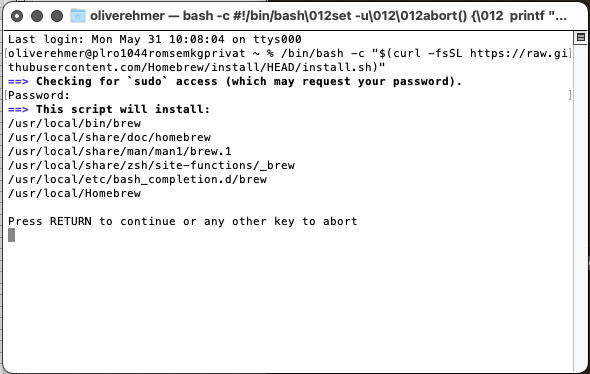

Make sure that the installation is complete. It is only complete when the prompt appears again at the end of the process.

##### (3) Installing *FFmpeg*

In the terminal, enter the following command:

`brew install ffmpeg`

To update to a newer version of FFmpeg, you can use the following command:

`brew upgrade ffmpeg`

##### (4) Testing the installation

To test whether the installation was successful, enter the following command in the terminal window:

`ffmpeg -version`

If multiple lines appear, the installation was successful.

# German

## Windows

Für die Installation von *FFmpeg* unter *Windows* muss das Programm heruntergeladen und darüber hinaus in einer Umgebungsvariable festgelegt werden, wo sich das Programm befindet. Dies ist notwendig, damit *FFmpeg* in der Eingabeaufforderung bzw. im Terminal einfach gestartet werden kann. Die hierfür notwendigen Schritte werden im Folgenden für *Windows 10* erläutert.

##### (1) Herunterladen

Auf der folgenden Seite kann *FFmpeg* heruntergeladen werden:

https://github.com/BtbN/FFmpeg-Builds/releases

Auf dieser Seite wird *FFmpeg* für verschiedene Betriebssysteme und unter verschiedenen Open Source-Lizenzen angeboten. Achten Sie darauf, dass Sie eine .zip-Datei laden, die `win64` im Namen enthält, z.B. die folgende:

`ffmpeg-N-102754-g604924a069-win64-lgpl.zip`

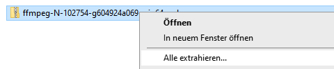

##### (3) Umbenennen des Ordners

Nach dem Entpacken erhalten Sie einen Ordner mit dem Gesamtnamen der ursprünglichen .zip-Datei. Darin befindet sich ein Unterordner, der denselben Namen trägt.

Benennen Sie diesen Ordner um in `ffmpeg` (Rechtsklick > „Umbenennen“

[figure not shown]

In diesem Ordner befinden sich zwei Unterordner mit den Namen `doc` und `bin`. Der Ordner doc enthält eine Dokumentation, der Ordner `bin` enthält verschiedene Programmdateien, unter diesen die Datei `ffmpeg.exe` .

##### (4) Verschieben des Ordners

Verschieben Sie den neu umbenannten Ordner `ffmpeg` auf die Hauptebene ihrer Festplatte `C:\` .

Wählen Sie hierzu zuerst den Ordner `ffmpeg` aus und drücken Sie die Tastenkombination *STRG + X* (zum Ausschneiden).

Navigieren Sie dann auf die Hauptebene Ihrer Festplatte `C:\` und drücken Sie die Tastenkombination *STRG + V* (zum Einfügen).

Danach müsste sich der Ordner ffmpeg auf der Hauptebene der Festplatte `C:\` befinden und direkt darin der Ordner `bin` enthalten sein.

[figure not shown]

##### (5) Erweiterte Systemeinstellungen öffnen

Geben Sie in der Suchleiste neben dem Startmenüsymbol den Begriff `Erweiterte Systemeinstellungen` ein.

[figure not shown]

Klicken Sie in der Liste der Suchergebnisse auf die App „Erweiterte Systemeinstellungen“.

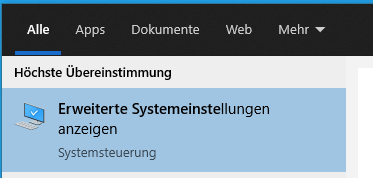

Es öffnet sich ein Fenster mit den „Systemeigenschaften“.

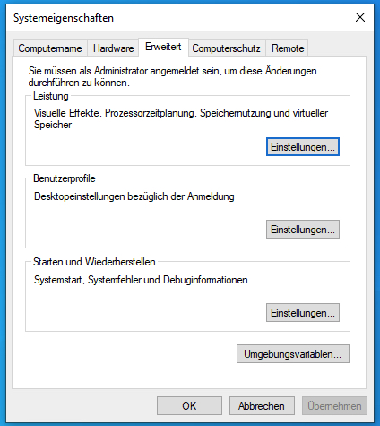

##### (6) Umgebungsvariablen öffnen

Wählen Sie in diesem Fenster „Umgebungsvariablen…“.

Es öffnet sich das Fenster „Umgebungsvariablen“.

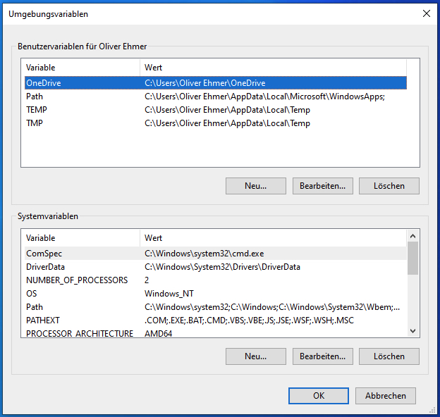